# SST Statistics for David Abel

Adam A. Kemberling

Updated on: 2021-08-18

# SST Patterns of New England

This report seeks to showcase how different areas in New England are warming in the larger context of the rest of the world and specific features of 2021.

The main focal areas are the Northeastern United States’ Continental Shelf, the Gulf of Maine, the Scotian Shelf, and the Bay of Fundy.

These are then compared to the warming rates of the world’s large marine ecosystems to place their trends among areas across the globe.

### Northeastern US Focal Regions

Each of the focal regions have been added to the {gmRi} package and can have their shapefile locations and temperature histories looked up with `gmRi::get_timeseries_paths()`

### Focal Region Map

For a visual, these are the areas we’ll be looking at:

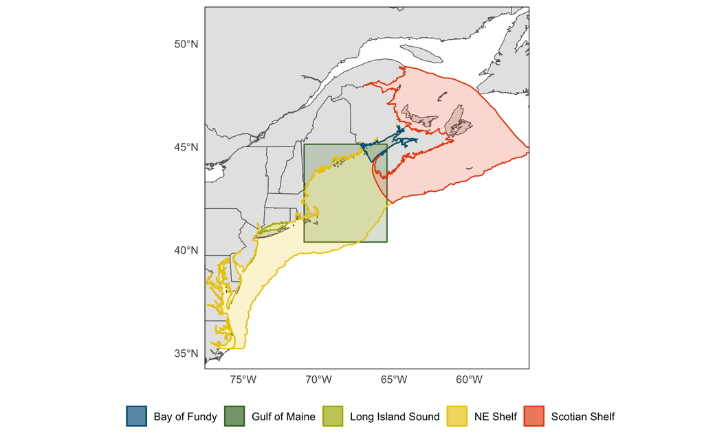

# Warming Rates

## Celsius

**Annual Change in Sea Surface Temperature**

Data from Years 1982-2020, Units: Celsius

| Region | Annual Change in Temperature |
| --- | --- |
| Global Oceans | 0.013 |
| Northeastern U.S. Shelf | 0.036 |
| Long Island Sound | 0.048 |
| Gulf of Maine | 0.041 |
| Scotian Shelf | 0.039 |
| Bay of Fundy | 0.064 |

*Data Source: NOAA OISSTv2 Daily Sea Surface Temperature Data.*  
*Reference Climatolgy Period: 1982-2011.*

## Fahrenheit

**Annual Change in Sea Surface Temperature**

Data from Years 1982-2020, Units: Fahrenheit

| Region | Annual Change in Temperature |
| --- | --- |
| Global Oceans | 0.024 |
| Northeastern U.S. Shelf | 0.066 |
| Long Island Sound | 0.087 |
| Gulf of Maine | 0.073 |
| Scotian Shelf | 0.071 |
| Bay of Fundy | 0.116 |

*Data Source: NOAA OISSTv2 Daily Sea Surface Temperature Data.*  
*Reference Climatolgy Period: 1982-2011.*

# Monthly Anomalies

## Celsius

**Average Temperature Anomalies - 2021**

Degrees Celsius Above Normal

| Region | Jan | Feb | Mar | Apr | May | Jun |
| --- | --- | --- | --- | --- | --- | --- |
| Global Oceans | 0.24 | 0.25 | 0.28 | 0.30 | 0.30 | 0.30 |
| Northeastern U.S. Shelf | 1.27 | 0.96 | 1.03 | 1.04 | 1.54 | 2.00 |
| Long Island Sound | 0.39 | 0.61 | 0.19 | 1.01 | 2.40 | 2.49 |
| Gulf of Maine | 1.80 | 1.58 | 1.03 | 1.23 | 1.78 | 2.60 |
| Scotian Shelf | 1.93 | 1.11 | 0.46 | 0.40 | 1.10 | 1.28 |
| Bay of Fundy | 3.09 | 2.76 | 2.30 | 2.57 | 3.32 | 2.78 |

*Data Source: NOAA OISSTv2 Daily Sea Surface Temperature Data.*  
*Reference Climatolgy Period: 1982-2011.*

## Fahrenheit

**Average Temperature Anomalies - 2021**

Degrees Fahrenheit Above Normal

| Region | Jan | Feb | Mar | Apr | May | Jun |
| --- | --- | --- | --- | --- | --- | --- |
| Global Oceans | 0.43 | 0.46 | 0.51 | 0.54 | 0.55 | 0.54 |
| Northeastern U.S. Shelf | 2.28 | 1.73 | 1.85 | 1.87 | 2.77 | 3.59 |
| Long Island Sound | 0.70 | 1.10 | 0.35 | 1.81 | 4.32 | 4.48 |
| Gulf of Maine | 3.23 | 2.84 | 1.85 | 2.21 | 3.21 | 4.68 |
| Scotian Shelf | 3.47 | 2.00 | 0.82 | 0.73 | 1.98 | 2.31 |
| Bay of Fundy | 5.56 | 4.96 | 4.13 | 4.63 | 5.98 | 5.00 |

*Data Source: NOAA OISSTv2 Daily Sea Surface Temperature Data.*  
*Reference Climatolgy Period: 1982-2011.*

# Recorded Temperature Increases

## Celsius

**Change in Annual Temperature**

| Region | 1982 Temp | 2020 Temp | Temp Change | Units |
| --- | --- | --- | --- | --- |
| Global Oceans | 13.44 | 13.96 | 0.52 | Celsius |
| Northeastern U.S. Shelf | 11.60 | 13.16 | 1.56 | Celsius |
| Long Island Sound | 10.26 | 13.51 | 3.25 | Celsius |
| Gulf of Maine | 9.91 | 11.35 | 1.44 | Celsius |
| Scotian Shelf | 7.28 | 8.28 | 1.00 | Celsius |
| Bay of Fundy | 6.73 | 9.10 | 2.37 | Celsius |

*Data Source: NOAA OISSTv2 Daily Sea Surface Temperature Data.*

## Fahrenheit

**Change in Annual Temperature**

| Region | 1982 Temp | 2020 Temp | Temp Change | Units |
| --- | --- | --- | --- | --- |
| Global Oceans | 56.18 | 57.12 | 0.94 | Fahrenheit |
| Northeastern U.S. Shelf | 52.87 | 55.69 | 2.82 | Fahrenheit |
| Long Island Sound | 50.47 | 56.31 | 5.84 | Fahrenheit |
| Gulf of Maine | 49.84 | 52.43 | 2.59 | Fahrenheit |
| Scotian Shelf | 45.10 | 46.91 | 1.81 | Fahrenheit |
| Bay of Fundy | 44.12 | 48.38 | 4.26 | Fahrenheit |

*Data Source: NOAA OISSTv2 Daily Sea Surface Temperature Data.*

# Warming Rate Rankings

**Table of Top Ten LME’s**

**Ranking Warming Across Large Marine Ecosystems**

| Region | Warming Rank | Warming Rate C | Warming Rate F |
| --- | --- | --- | --- |
| Bay Of Fundy | 1 | 0.064 | 0.116 |
| Long Island Sound | 2 | 0.048 | 0.087 |
| Baltic Sea | 3 | 0.047 | 0.085 |
| Black Sea | 4 | 0.046 | 0.083 |
| Gulf Of Maine | 5 | 0.041 | 0.073 |
| Iceland Shelf And Sea | 6 | 0.040 | 0.072 |
| Scotian Shelf | 7 | 0.040 | 0.071 |
| Northeast Us Continental Shelf | 8 | 0.036 | 0.065 |
| North Sea | 9 | 0.036 | 0.065 |
| Norwegian Sea | 10 | 0.033 | 0.059 |
| Barents Sea | 11 | 0.031 | 0.056 |
| Mediterranean Sea | 12 | 0.031 | 0.055 |
| West Bering Sea | 13 | 0.030 | 0.054 |

*Data Source: NOAA OISSTv2 Daily Sea Surface Temperature Data. Temperatures adjusted for latitudinal distotion.*  
*Gulf of Maine, Long Island Sound, and Bay of fundy not true LME's*

**Plotting Absolute Changes 1982-2020**

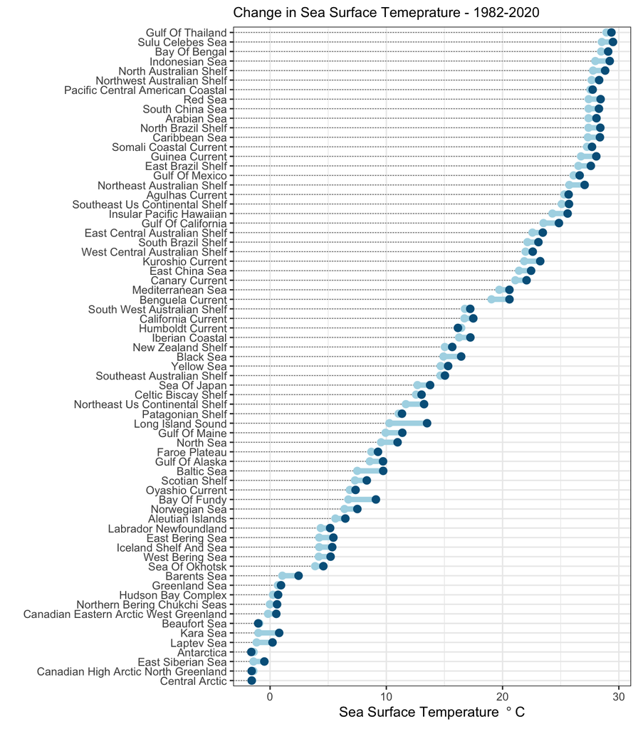

# 2020 in the Gulf of Maine

# 2021 in the Gulf of Maine

A marine heatwave is defined a when seawater temperatures exceed a seasonally-varying threshold (usually the 90th percentile) for at least 5 consecutive days. Successive heatwaves with gaps of 2 days or less are considered part of the same event.

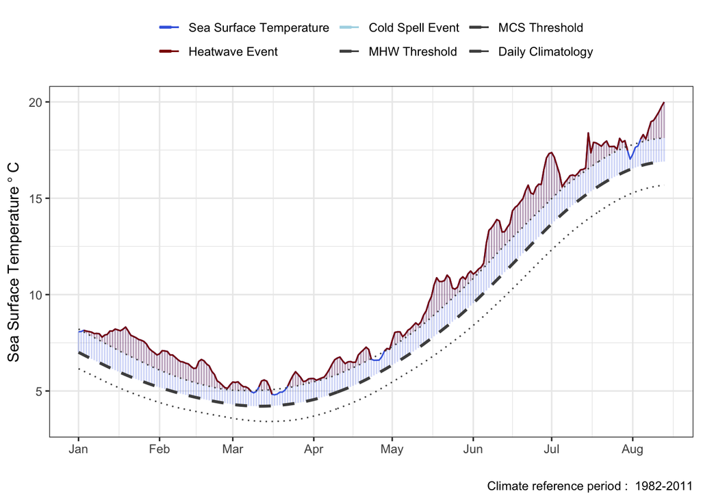

# Gulf of Maine Heatwave Record

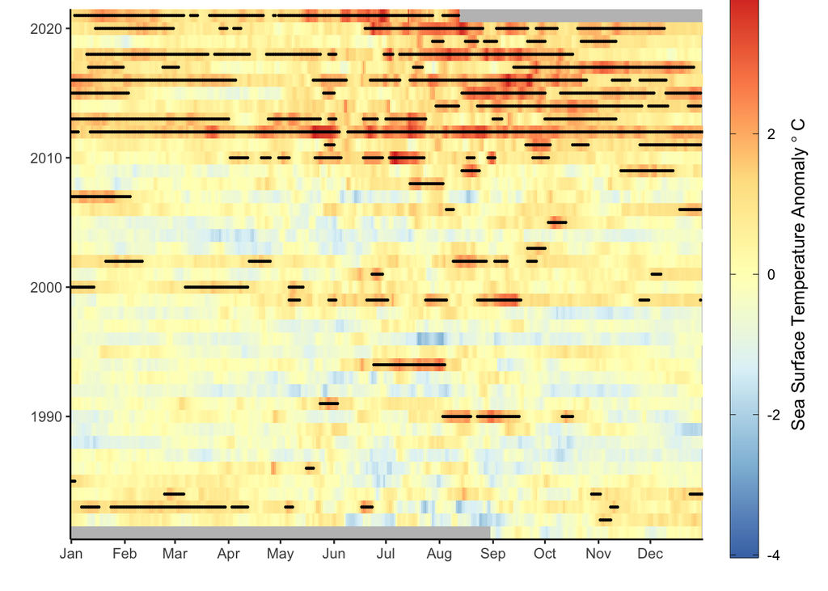

## Heatwave Trends

This section is for looking more closely at how patterns in heatwave events are progressing. For each year summaries for the number of heatwaves, their average duration, and their peak temperatures are recorded.

### World

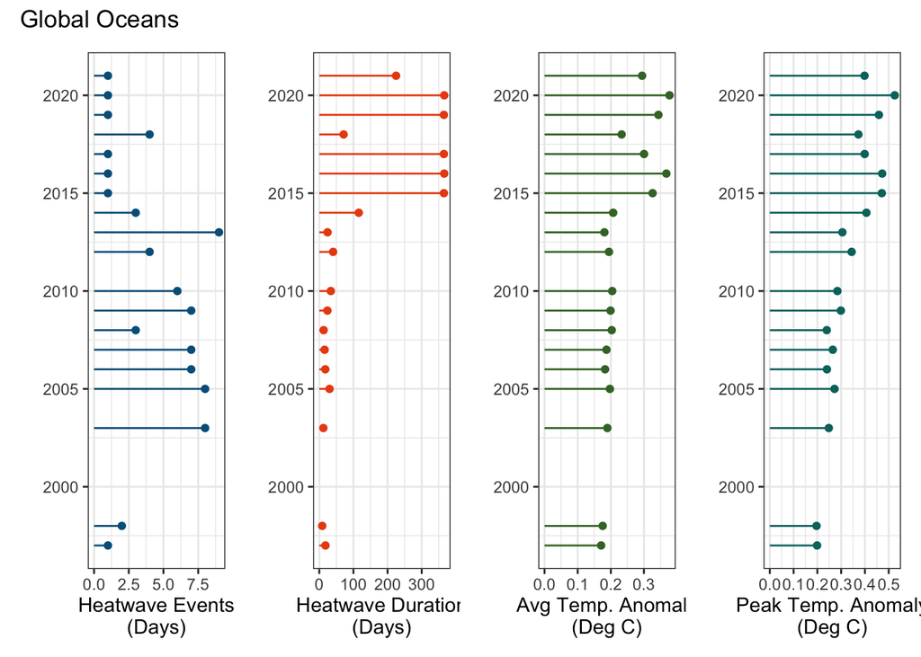

### Northeast Shelf

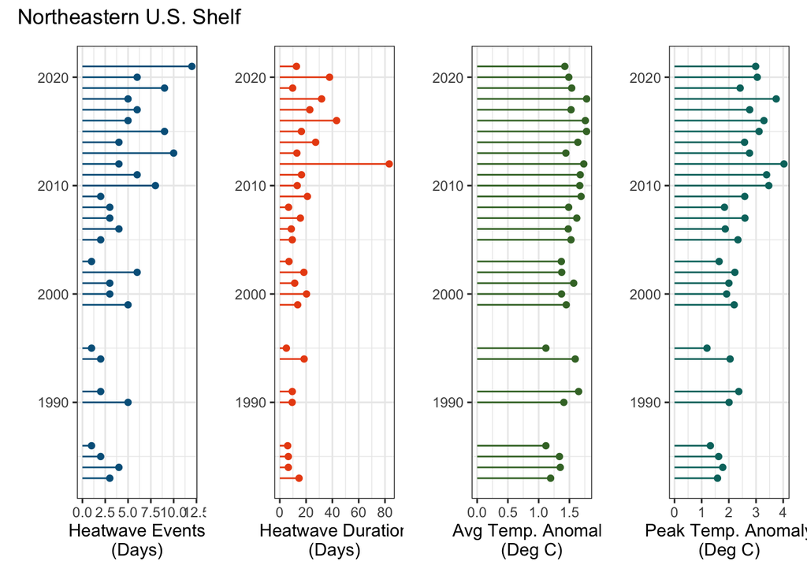

### Gulf of Maine

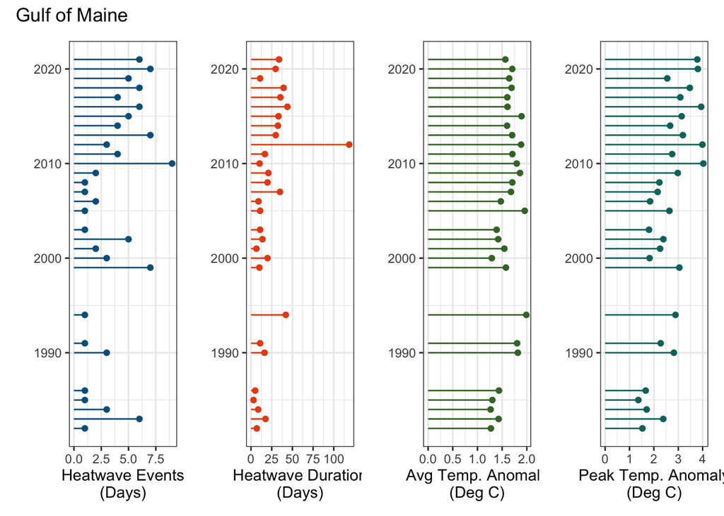

### Bay of fundy

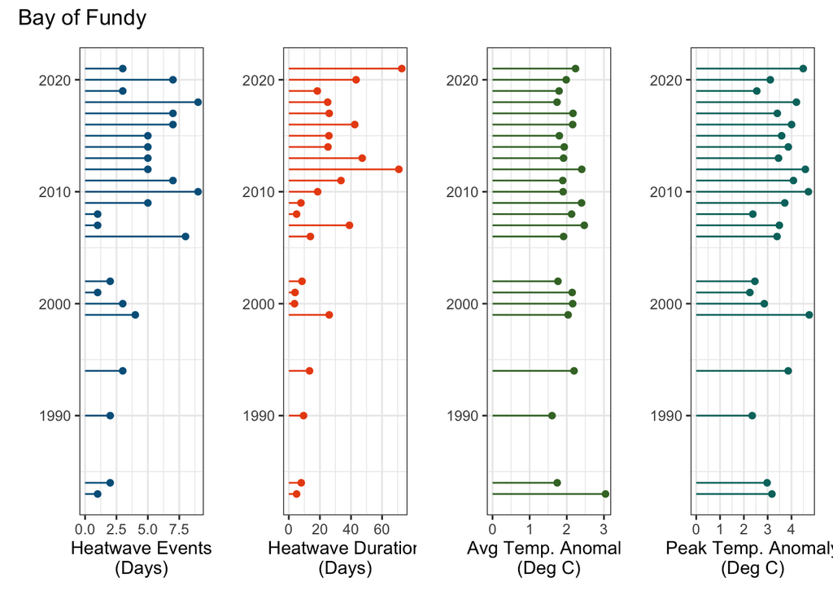

### Scotian Shelf

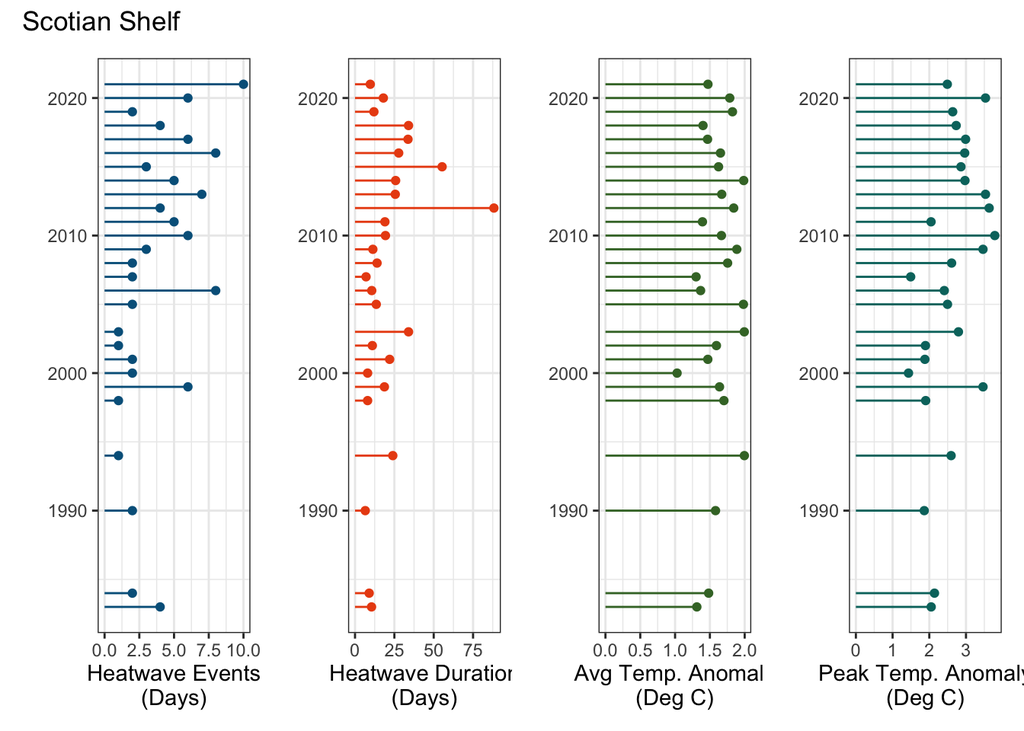

### Long Island Sound

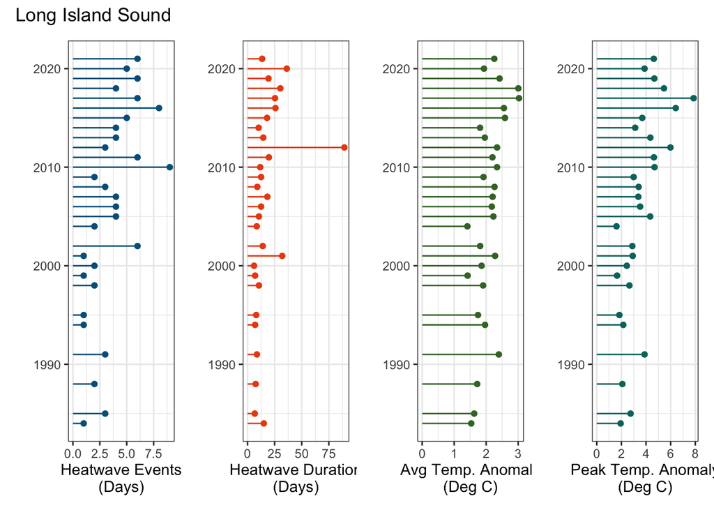

## Gulf of Maine 2021 Highlights

**Why flag 2012?** In many ways 2012 was an exceptionally hot year, maintaining temperatures above marine heatwave threshold for nearly the entire year. For comparison purposes 2012 has also been flagged as it is the hottest year on recent record.

This section seeks to place the monthly temperatures in the context of previous years for the purpose of answering:

- Is this the hottest month on record?
- If not, when was it hotter?
- If so, when was the runner up?
- Top 5?

**Summary Prep**

### Average Temperature

The average monthly temperature is fairly straightforward, and is useful for grounding these metrics in physical units rather than “anomalies”.

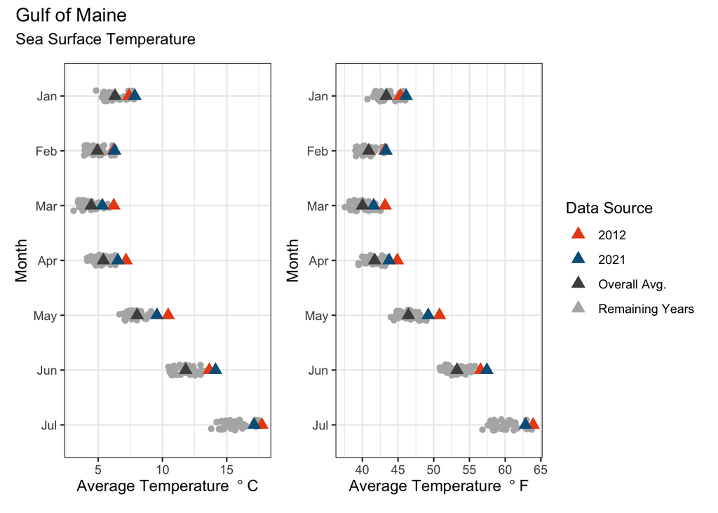

### Average Anomaly

The average daily anomaly sets the benchmark for how far from the climate average a particular month is.

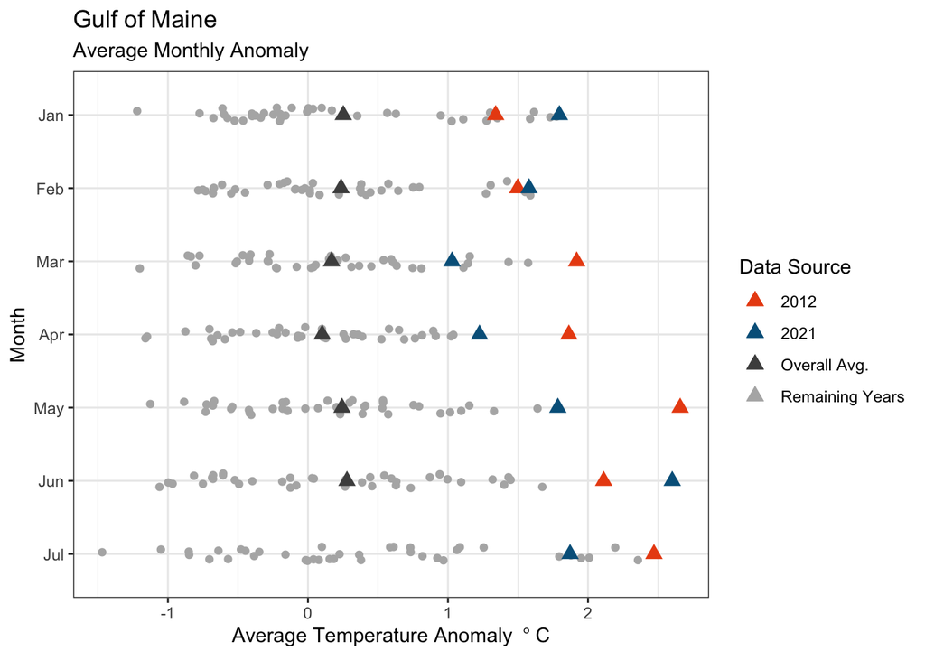

### Anomaly Strength

Peak daily anomalies are indicative of acute thermal stress and may put species over their thermal stress limits if they are unable move/adapt to avoid/cope with them.

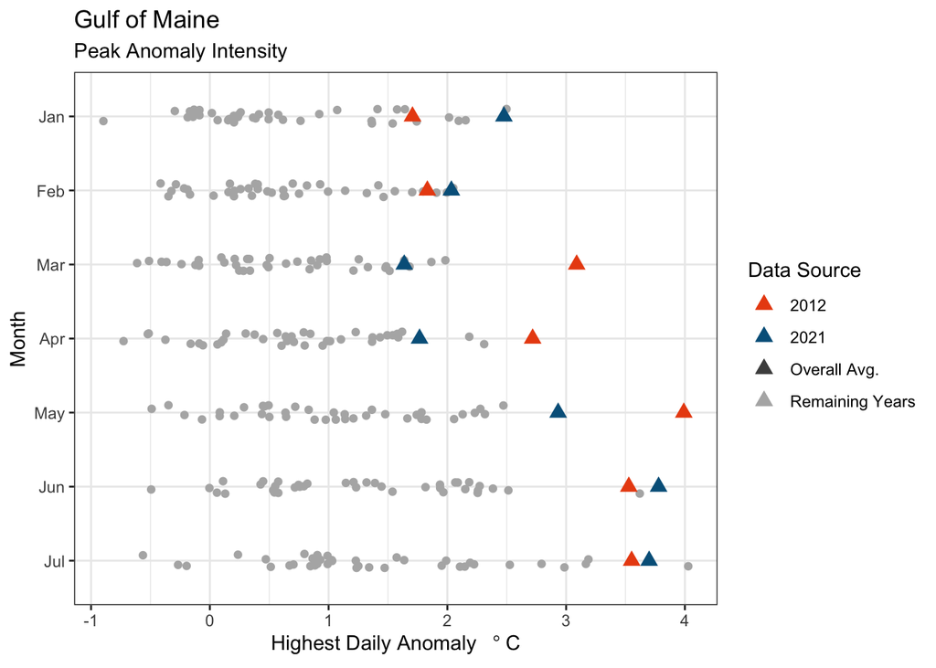

### Smallest Anomaly

The smallest or lowest anomaly temperature is a useful indication of temperature relief, or a break from thermal stress. A high minimum anomaly value is indicative that even “troughs” in temperature may still be stressful.

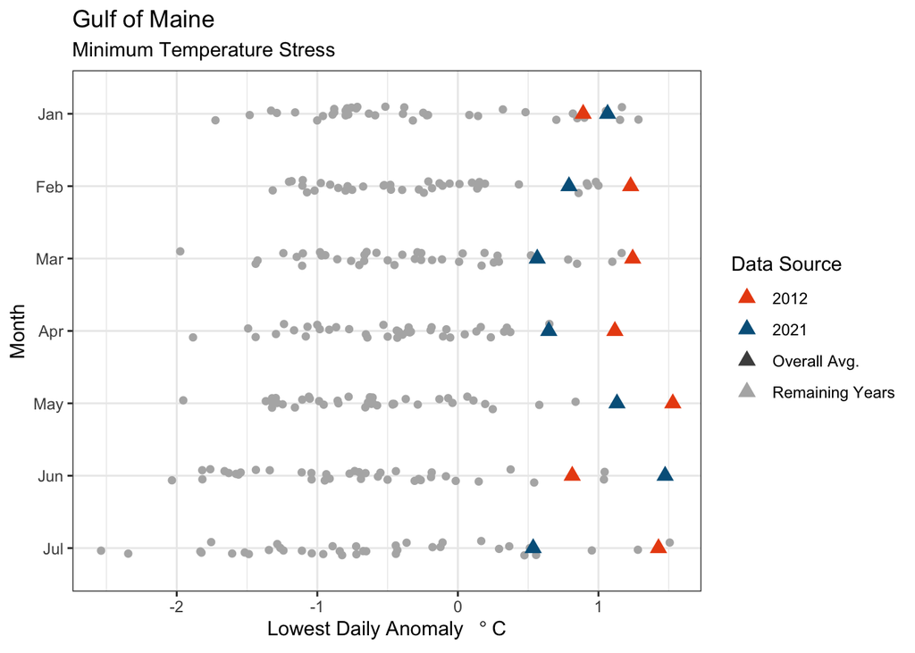

### Total Temperature Distance

The additive total of daily anomalies is a proxy that tracks the excess amount of temperature in the system.

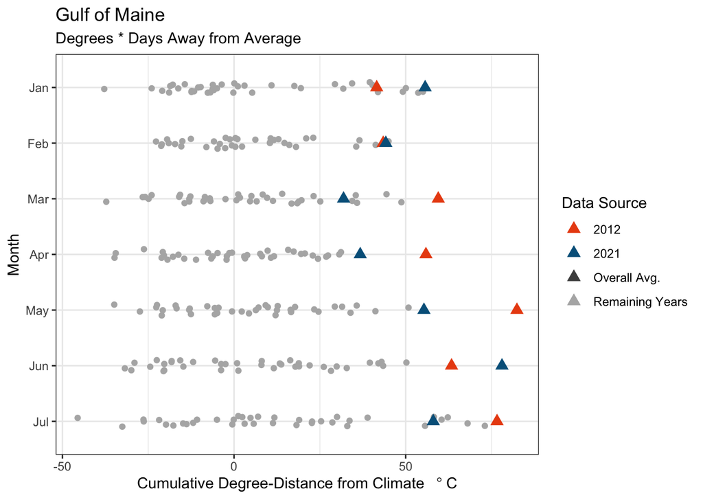

# 2021 in New England

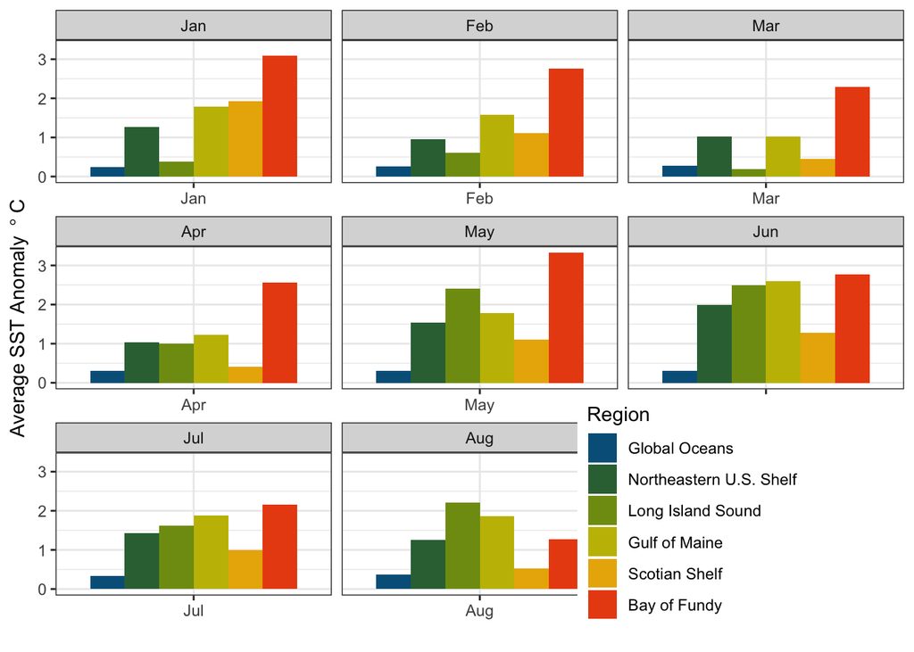

# Maps

## World

### Jan

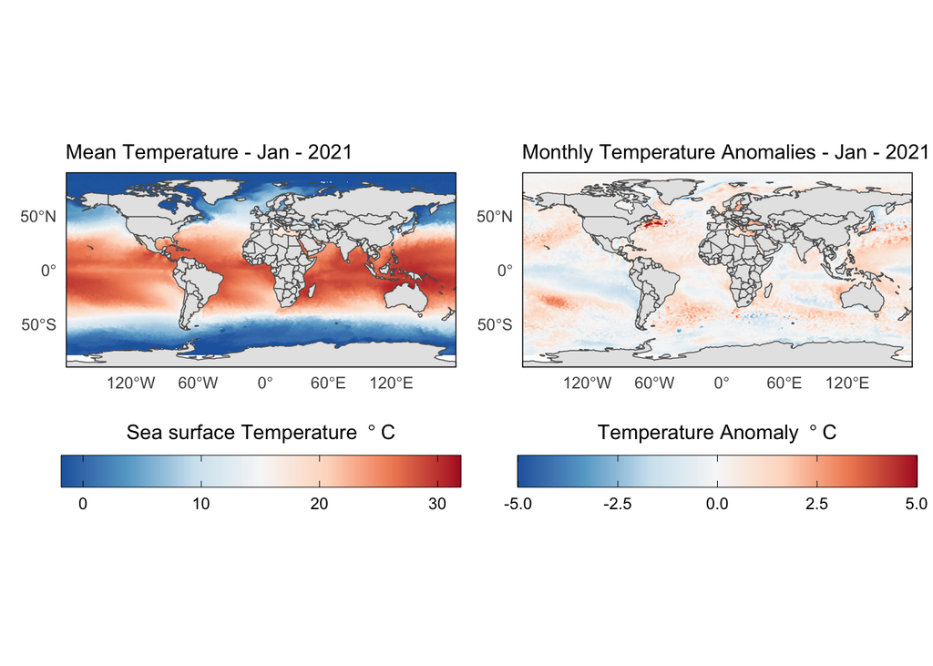

### Feb

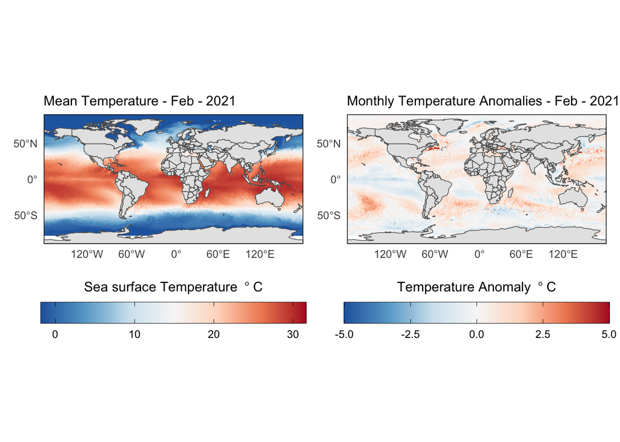

### Mar

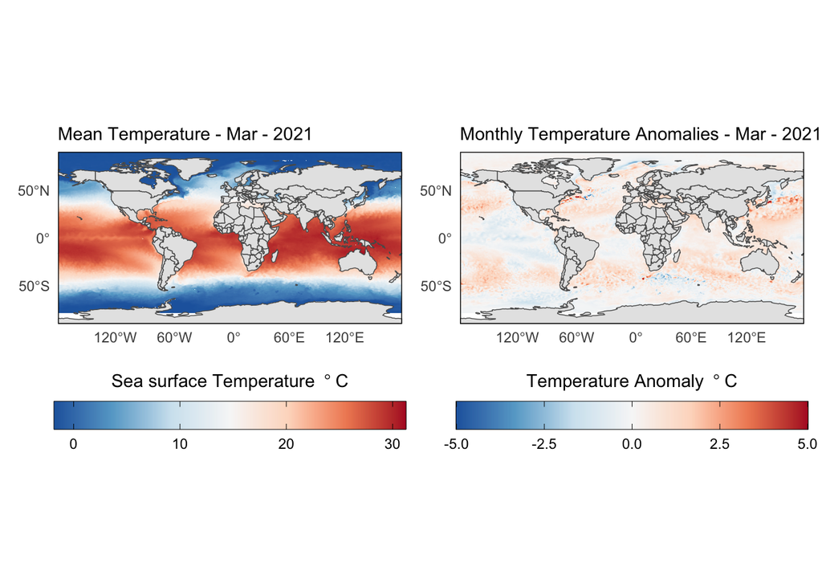

### Apr

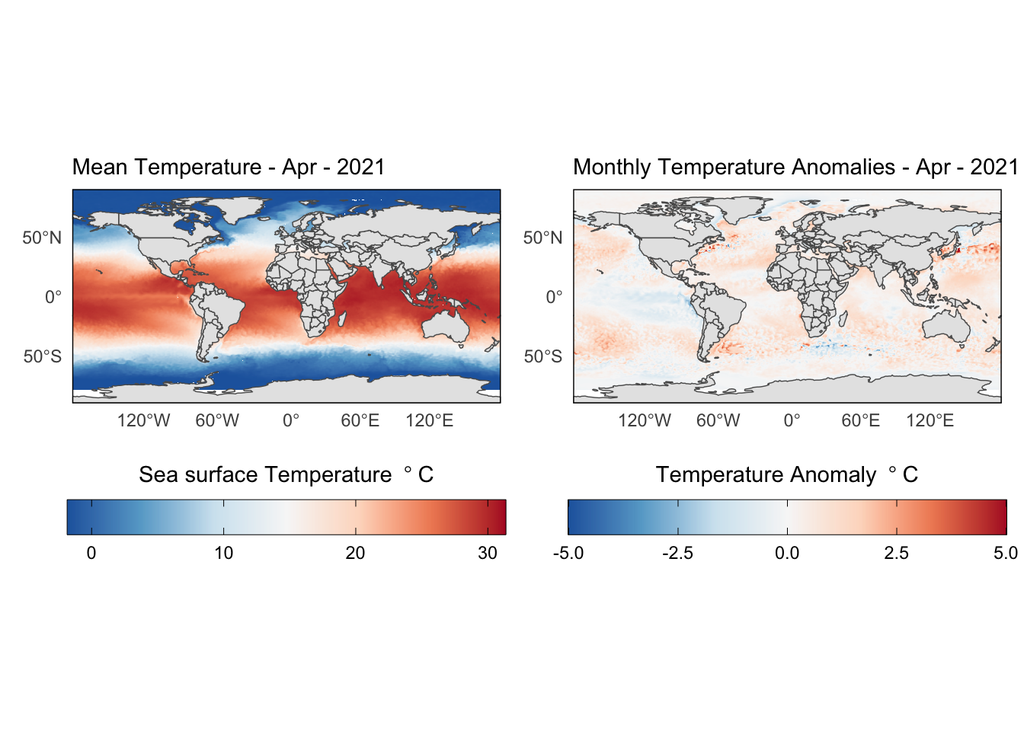

### May

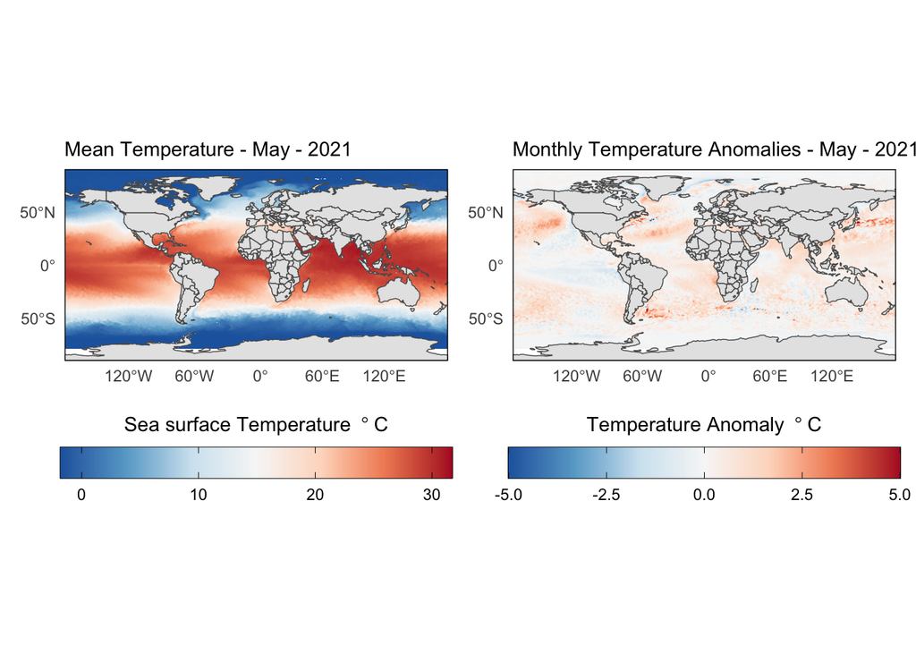

### Jun

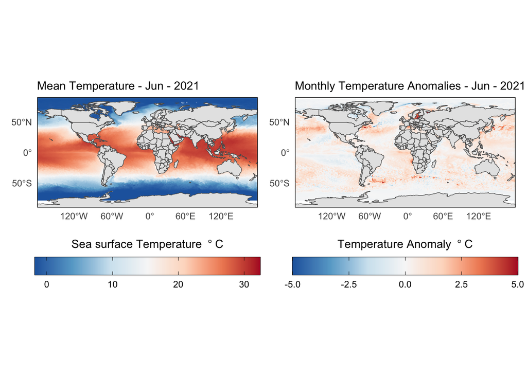

### Jul

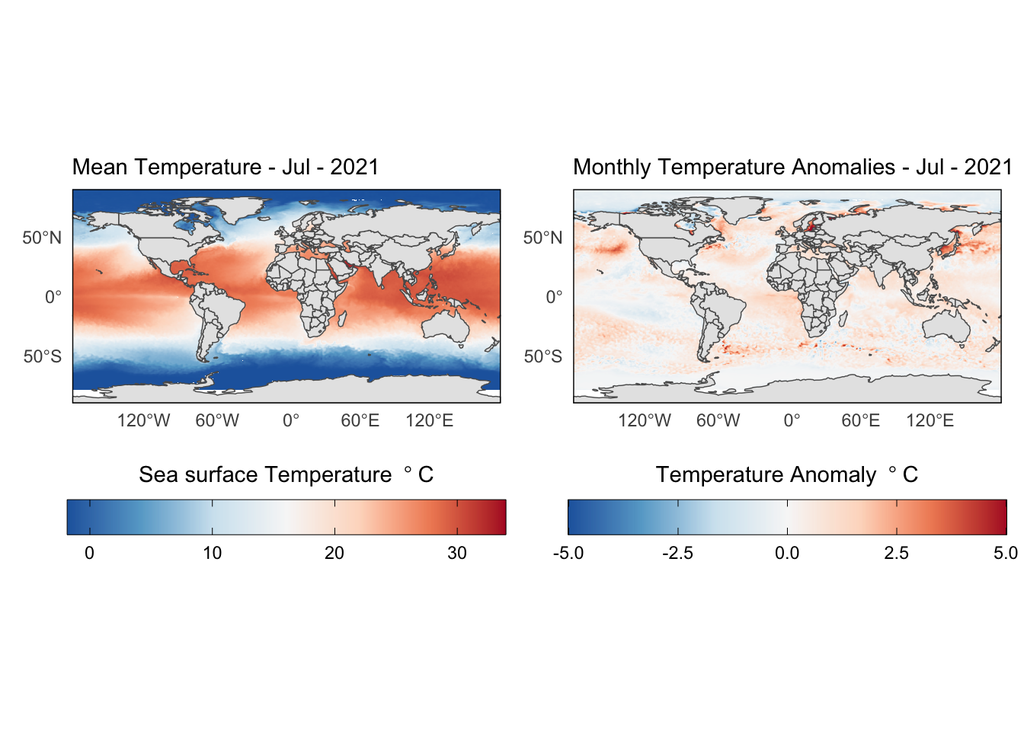

## Northeastern US Shelf

### Jan

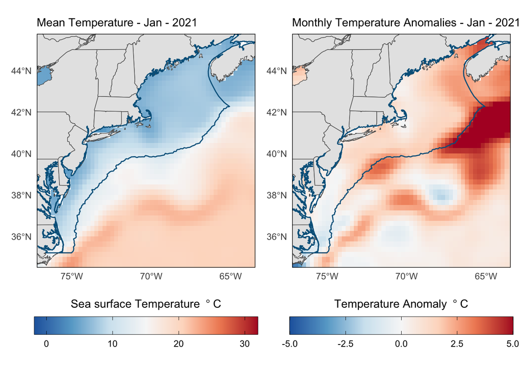

### Feb

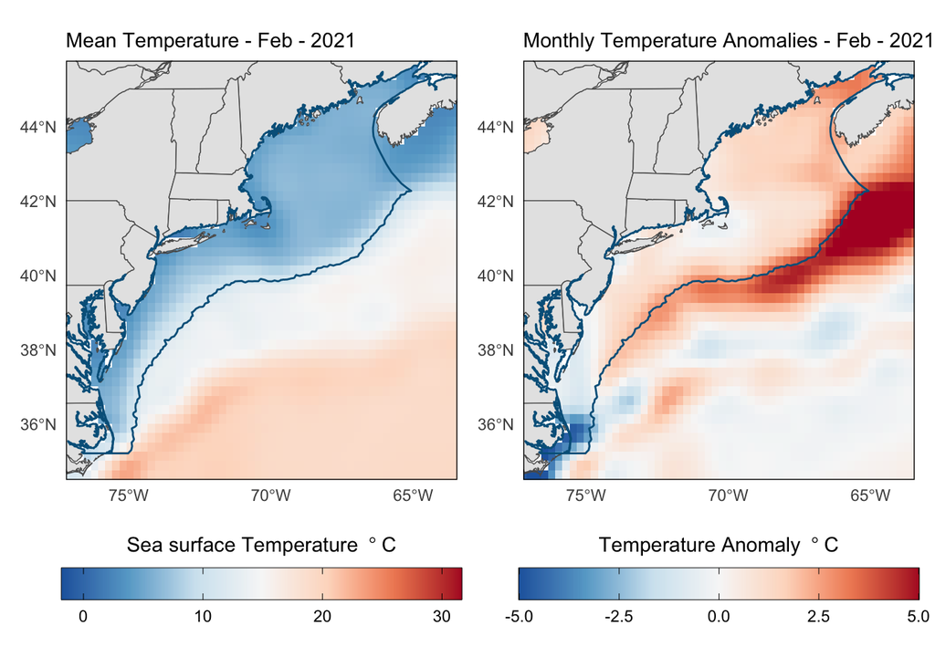

### Mar

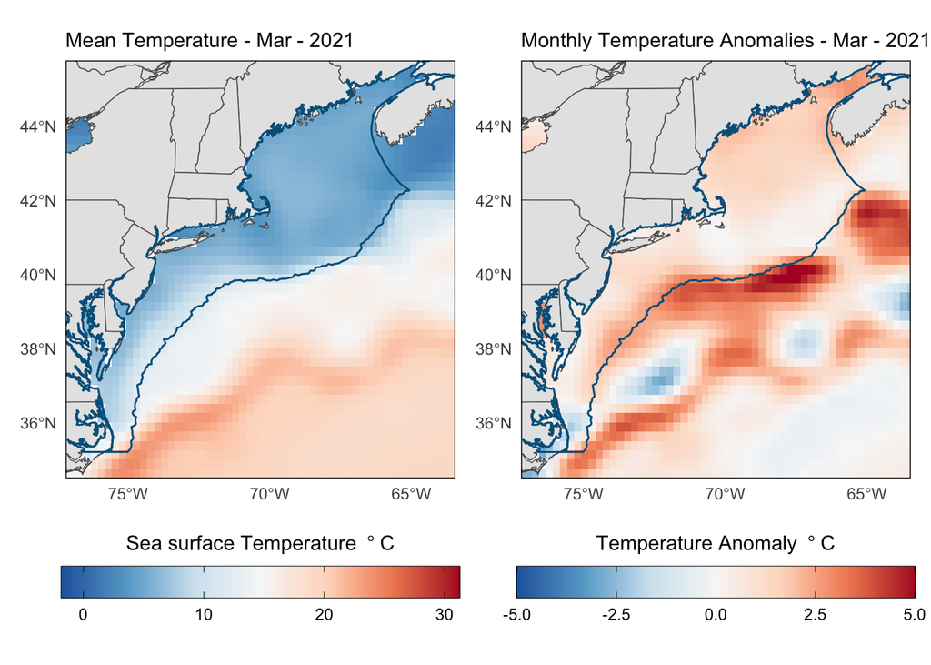

### Apr

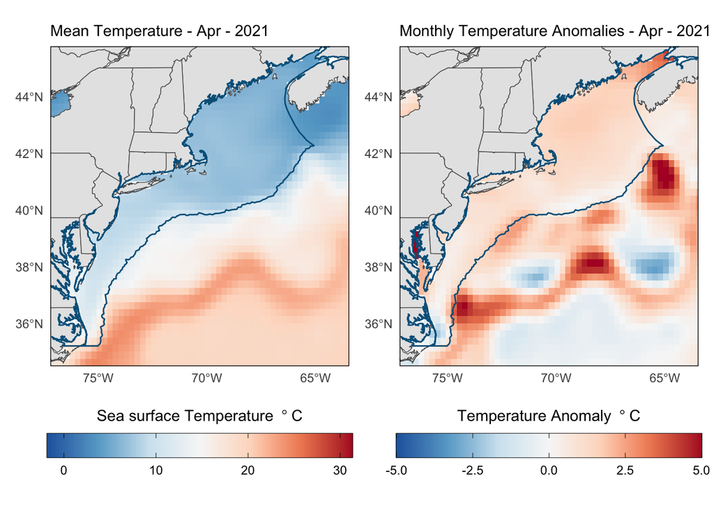

### May

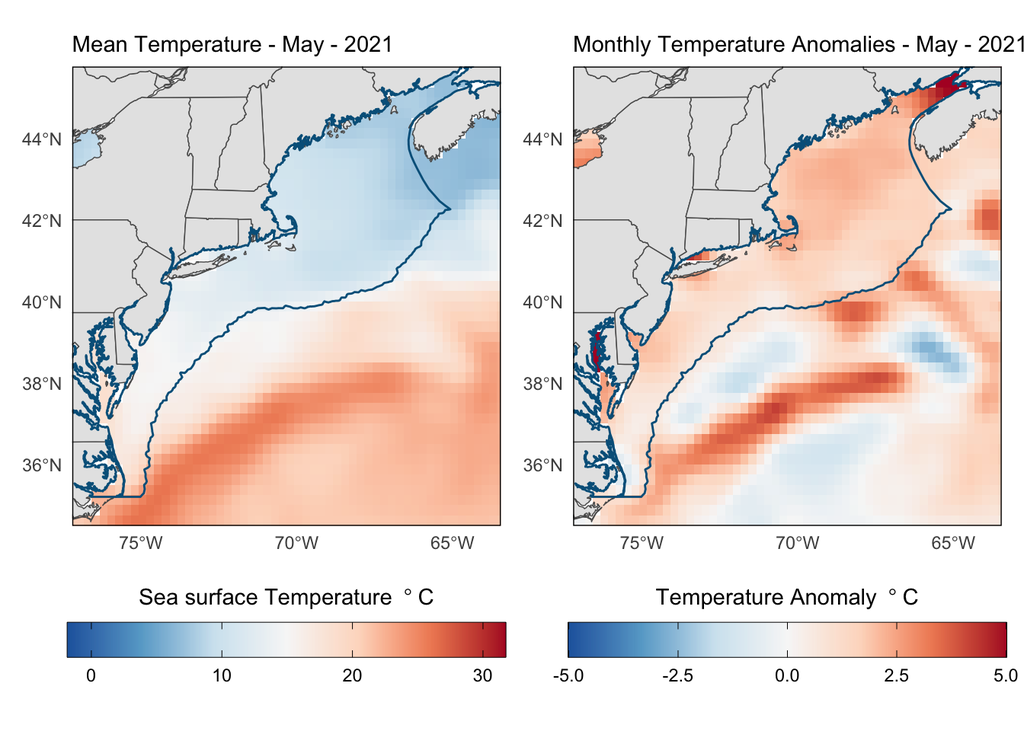

### Jun

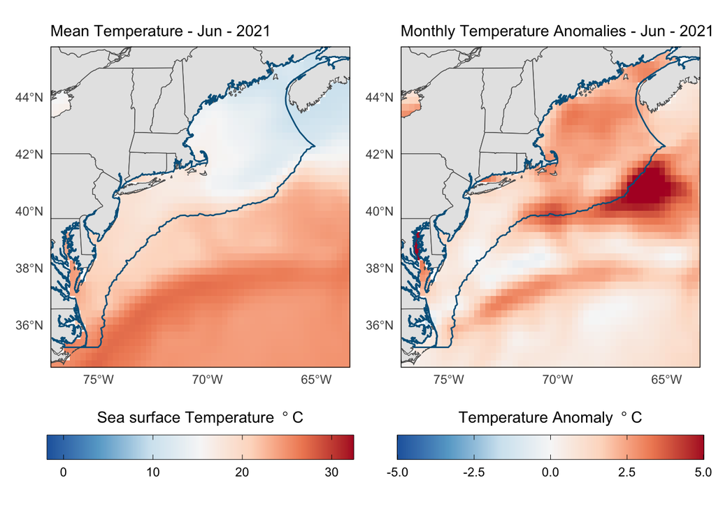

### Jul

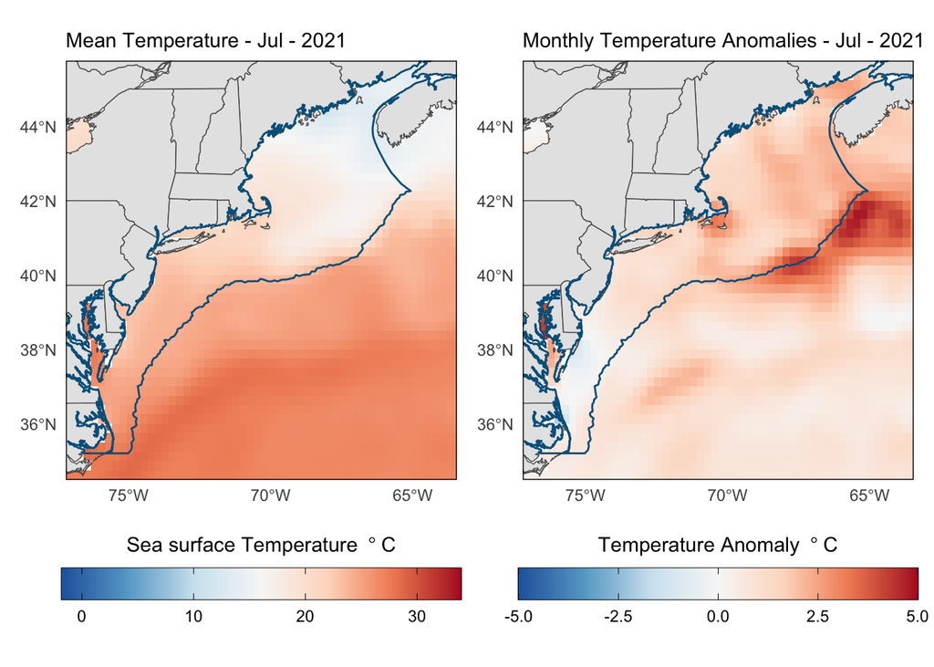

## Gulf of Maine

### Jan

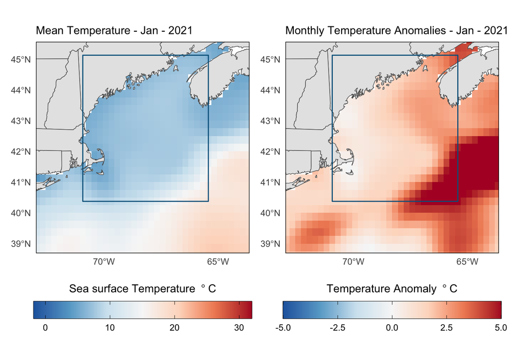